# Strategy 3: State-Space and Regime-Switching Analysis of the TIPS–Treasury Basis

This notebook implements Strategy 3 by decomposing the observed TIPS–Treasury mispricing spread into a slowly evolving structural component and a mean-reverting deviation. We complement the state-space decomposition with regime-switching autoregressive models to capture shifts between fast and slow reversion environments, aligning the inferences with macro and market events.

## Objectives

1. Load the mispricing basis along with auxiliary covariates and macro event tags, resolving minor data gaps while flagging longer outages.
2. Estimate a local level + AR(1) state-space model to separate the structural mean from the transient component for key tenors.
3. Fit regime-switching AR(1) models to the detrended residuals, allowing intervention dummies to modify regime dynamics.
4. Summarize filtered and smoothed state estimates, parameter posteriors, regime transition diagnostics, and half-life comparisons.
5. Interpret the persistence decomposition, relate regime switches to events, and benchmark against prior AR(1)/EWMA half-life findings.

```python
import warnings
from pathlib import Path
from typing import Dict, List, Tuple

import numpy as np
import pandas as pd
import statsmodels.api as sm
from matplotlib import pyplot as plt
from pandas.tseries.offsets import BDay
from statsmodels.stats.diagnostic import acorr_ljungbox, het_arch
from statsmodels.tsa.regime_switching.markov_autoregression import MarkovAutoregression

warnings.filterwarnings('ignore')
pd.set_option('display.max_columns', 40)
pd.set_option('display.width', 120)

PROJECT_ROOT = Path('..').resolve()
DATA_DIR = PROJECT_ROOT / '_data'
REF_DIR = PROJECT_ROOT / '_ref'
OUTPUT_DIR = PROJECT_ROOT / '_output' / 'strategy3'
OUTPUT_DIR.mkdir(parents=True, exist_ok=True)
```

```python
def half_life(phi: float) -> float:
    """Convert an AR(1) coefficient into a half-life in business days."""
    if pd.isna(phi):
        return np.nan
    if abs(phi) >= 0.999:
        return np.inf
    if abs(phi) < 1e-6:
        return 0.0
    return float(np.log(0.5) / np.log(abs(phi)))


def write_with_metadata(df: pd.DataFrame, path: Path, meta: List[str]) -> None:
    lines = [f"# {line}" for line in meta]
    with path.open('w', encoding='utf-8') as fh:
        for line in lines:
            fh.write(f"{line}\n")
        df.to_csv(fh, index=False)
```

```python
def summarize_gaps(panel: pd.DataFrame, max_fill: int = 3) -> pd.DataFrame:
    records = []
    for tenor, grp in panel.groupby('tenor'):
        grp = grp.sort_values('date')
        grp = grp.set_index('date').asfreq('B')
        missing = grp['basis'].isna()
        if missing.any():
            block_id = (missing != missing.shift()).cumsum()
            grp['gap_len'] = missing.groupby(block_id).transform('sum')
            gap_info = grp[missing].drop_duplicates(subset='gap_len')
            for idx, row in gap_info.iterrows():
                records.append({
                    'tenor': tenor,
                    'start': idx,
                    'end': idx + BDay(row['gap_len'] - 1) if row['gap_len'] > 0 else idx,
                    'length': int(row['gap_len'])
                })
    gap_df = pd.DataFrame(records)
    if gap_df.empty:
        return pd.DataFrame(columns=['tenor', 'start', 'end', 'length', 'action'])
    gap_df['action'] = np.where(gap_df['length'] <= max_fill, 'interpolate', 'flag')
    return gap_df


def prepare_panel() -> Tuple[pd.DataFrame, pd.DataFrame]:
    basis_path = DATA_DIR / 'mispricing_basis.csv'
    raw_basis = pd.read_csv(basis_path, parse_dates=['date'])
    events_path = REF_DIR / 'events.csv'
    events = pd.read_csv(events_path, parse_dates=['date'])
    basis = raw_basis.copy()
    basis['tenor'] = basis['tenor'].astype(int)

    gap_summary = summarize_gaps(basis)

    filled_records = []
    for tenor, grp in basis.groupby('tenor'):
        grp = grp.sort_values('date').set_index('date')
        grp = grp.asfreq('B')
        grp['basis'] = grp['basis'].interpolate(limit=3, limit_direction='both')
        grp['tenor'] = tenor
        grp['was_missing'] = grp['basis'].isna()
        filled_records.append(grp.reset_index())
    filled = pd.concat(filled_records, ignore_index=True)

    event_flags = (events.assign(flag=1)
                   .pivot_table(index='date', columns='event_type', values='flag', aggfunc='sum')
                   .fillna(0))
    core_cols = ['cpi_release', 'fomc_statement', 'tips_auction', 'tips_auction_announce', 'tips_auction_settlement']
    for col in core_cols:
        if col not in event_flags.columns:
            event_flags[col] = 0
    event_flags = event_flags.reindex(filled['date'].unique(), fill_value=0)
    event_flags = event_flags.sort_index()

    panel = filled.merge(event_flags.reset_index(), on='date', how='left')
    panel[core_cols] = panel[core_cols].fillna(0)

    panel['basis_change'] = panel.groupby('tenor')['basis'].diff()
    panel['abs_basis'] = panel['basis'].abs()
    panel['roll_vol_21'] = panel.groupby('tenor')['basis'].transform(lambda s: s.rolling(21, min_periods=5).std())
    panel['roll_vol_63'] = panel.groupby('tenor')['basis'].transform(lambda s: s.rolling(63, min_periods=10).std())
    panel['roll_zscore'] = panel.groupby('tenor')['basis'].transform(lambda s: (s - s.rolling(63, min_periods=10).mean()) / s.rolling(63, min_periods=10).std())

    return panel, gap_summary
```

```python
panel, gap_summary = prepare_panel()
print('Panel rows:', len(panel))
print('Gap summary rows:', len(gap_summary))
panel.head()
```

```
Panel rows: 15648
Gap summary rows: 7
```

|  | date | tenor | basis | was_missing | cpi_release | fomc_minutes | fomc_statement | tips_auction | tips_auction_announce | tips_auction_settlement | treasury_refunding | basis_change | abs_basis | roll_vol_21 | roll_vol_63 | roll_zscore |
| --- | --- | --- | --- | --- | --- | --- | --- | --- | --- | --- | --- | --- | --- | --- | --- | --- |
| 0 | 2010-01-04 | 2 | 43.534609 | False | 0.0 | 0.0 | 0.0 | 0.0 | 0.0 | 0.0 | 0.0 | NaN | 43.534609 | NaN | NaN | NaN |
| 1 | 2010-01-05 | 2 | 39.490811 | False | 0.0 | 0.0 | 0.0 | 0.0 | 0.0 | 0.0 | 0.0 | -4.043798 | 39.490811 | NaN | NaN | NaN |
| 2 | 2010-01-06 | 2 | 38.344764 | False | 0.0 | 0.0 | 0.0 | 0.0 | 0.0 | 0.0 | 0.0 | -1.146048 | 38.344764 | NaN | NaN | NaN |
| 3 | 2010-01-07 | 2 | 30.474542 | False | 0.0 | 0.0 | 0.0 | 0.0 | 0.0 | 0.0 | 0.0 | -7.870222 | 30.474542 | NaN | NaN | NaN |
| 4 | 2010-01-08 | 2 | 40.810449 | False | 0.0 | 0.0 | 0.0 | 0.0 | 0.0 | 0.0 | 0.0 | 10.335907 | 40.810449 | 4.901388 | NaN | NaN |

```python
gap_summary.head(10)
```

|  | tenor | start | end | length | action |
| --- | --- | --- | --- | --- | --- |
| 0 | 2 | 2010-01-18 | 2010-01-18 | 1 | interpolate |
| 1 | 2 | 2014-09-01 | 2014-09-02 | 2 | interpolate |
| 2 | 2 | 2015-08-27 | 2015-08-31 | 3 | interpolate |
| 3 | 2 | 2016-01-13 | 2016-01-18 | 4 | flag |
| 4 | 5 | 2010-01-18 | 2010-01-18 | 1 | interpolate |
| 5 | 10 | 2010-01-18 | 2010-01-18 | 1 | interpolate |
| 6 | 20 | 2010-01-18 | 2010-01-18 | 1 | interpolate |

```python
tenors = sorted(panel['tenor'].unique())
print('Tenors in panel:', tenors)
```

```
Tenors in panel: [2, 5, 10, 20]
```

### Preliminary Trend in the Mispricing Basis

The chart below shows the business-day interpolated mispricing spread for each tenor, highlighting the slow-moving level shifts compared with higher-frequency deviations.

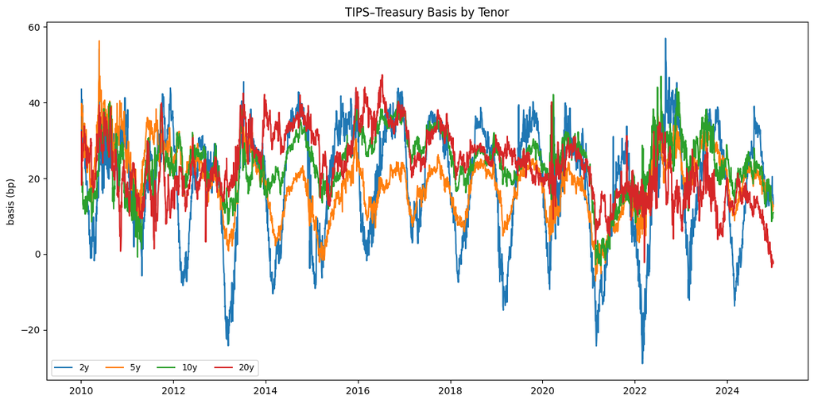

```python
fig, ax = plt.subplots(figsize=(12, 6))
for tenor in tenors:
    sub = panel[panel['tenor'] == tenor].set_index('date')
    ax.plot(sub.index, sub['basis'], label=f'{tenor}y')
ax.set_title('TIPS–Treasury Basis by Tenor')
ax.set_ylabel('basis (bp)')
ax.legend(ncol=4, fontsize=9)
plt.tight_layout()
plt.show()
```

## State-Space Decomposition

We estimate a local-level + AR(1) model for each tenor. The level captures the slow-moving component ((\mu_t)), while the AR(1) component describes the deviation ((\varepsilon_t)).

```python
state_records = []
parameter_rows = []
variance_share = []
state_diagnostics = []
state_models: Dict[int, object] = {}

for tenor in tenors:
    series = (panel[panel['tenor'] == tenor]
              .set_index('date')['basis']
              .astype(float)
              .sort_index())
    series = series.asfreq('B')
    series = series.interpolate(limit=3, limit_direction='both').dropna()

    mod = sm.tsa.UnobservedComponents(series, level='local level', autoregressive=1)
    res = mod.fit(disp=False)
    state_models[tenor] = res

    mu_smoothed = pd.Series(res.smoothed_state[0], index=series.index, name='mu_smoothed')
    mu_filtered = pd.Series(res.filtered_state[0], index=series.index, name='mu_filtered')
    epsilon_smoothed = series - mu_smoothed
    epsilon_filtered = series - mu_filtered

    phi = dict(zip(res.param_names, res.params)).get('ar.L1', np.nan)
    hl = half_life(phi)

    parameter_rows.append({
        'tenor': tenor,
        'model': 'state_space',
        'parameter': 'phi',
        'value': phi,
        'half_life_days': hl
    })
    for pname, pval in zip(res.param_names, res.params):
        if pname != 'autoregressive.ar.L1':
            parameter_rows.append({
                'tenor': tenor,
                'model': 'state_space',
                'parameter': pname,
                'value': pval,
                'half_life_days': np.nan
            })

    var_mu = np.var(mu_smoothed)
    var_eps = np.var(epsilon_smoothed)
    variance_share.append({
        'tenor': tenor,
        'component': 'structural_mean',
        'variance': var_mu
    })
    variance_share.append({
        'tenor': tenor,
        'component': 'deviation',
        'variance': var_eps
    })

    hf_smoothed = res.filter_results.standardized_forecasts_error[0]
    ljung = acorr_ljungbox(hf_smoothed, lags=[5, 10, 21], return_df=True)
    arch_test = het_arch(hf_smoothed, maxlag=5)
    state_diagnostics.append({
        'tenor': tenor,
        'test': 'Ljung-Box p(5)',
        'stat': ljung['lb_stat'].iloc[0],
        'pvalue': ljung['lb_pvalue'].iloc[0]
    })
    state_diagnostics.append({
        'tenor': tenor,
        'test': 'Ljung-Box p(21)',
        'stat': ljung['lb_stat'].iloc[-1],
        'pvalue': ljung['lb_pvalue'].iloc[-1]
    })
    state_diagnostics.append({
        'tenor': tenor,
        'test': 'ARCH LM p',
        'stat': arch_test[0],
        'pvalue': arch_test[1]
    })

    component_df = pd.DataFrame({
        'date': series.index,
        'tenor': tenor,
        'mu_smoothed': mu_smoothed.values,
        'mu_filtered': mu_filtered.values,
        'epsilon_smoothed': epsilon_smoothed.values,
        'epsilon_filtered': epsilon_filtered.values
    })
    state_records.append(component_df)

state_estimates = pd.concat(state_records, ignore_index=True)
parameter_estimates = pd.DataFrame(parameter_rows)
variance_decomposition = pd.DataFrame(variance_share)
state_diagnostics_df = pd.DataFrame(state_diagnostics)

state_estimates.head()
```

|  | date | tenor | mu_smoothed | mu_filtered | epsilon_smoothed | epsilon_filtered |
| --- | --- | --- | --- | --- | --- | --- |
| 0 | 2010-01-04 | 2 | 41.873280 | 43.534492 | 1.661329 | 0.000118 |
| 1 | 2010-01-05 | 2 | 39.624448 | 40.696540 | -0.133636 | -1.205728 |
| 2 | 2010-01-06 | 2 | 37.556523 | 39.114437 | 0.788241 | -0.769674 |
| 3 | 2010-01-07 | 2 | 34.421535 | 33.329334 | -3.946993 | -2.854792 |
| 4 | 2010-01-08 | 2 | 36.629697 | 38.335968 | 4.180752 | 2.474481 |

```python
parameter_estimates.head(12)
```

|  | tenor | model | parameter | value | half_life_days |
| --- | --- | --- | --- | --- | --- |
| 0 | 2 | state_space | phi | 9.064007e-01 | 7.053223 |
| 1 | 2 | state_space | sigma2.irregular | 2.702649e+00 | NaN |
| 2 | 2 | state_space | sigma2.level | 3.658647e+00 | NaN |
| 3 | 2 | state_space | sigma2.ar | 3.790033e-12 | NaN |
| 4 | 2 | state_space | ar.L1 | 9.064007e-01 | NaN |
| 5 | 5 | state_space | phi | 7.129953e-01 | 2.049031 |
| 6 | 5 | state_space | sigma2.irregular | 9.729229e-01 | NaN |
| 7 | 5 | state_space | sigma2.level | 9.073969e-01 | NaN |
| 8 | 5 | state_space | sigma2.ar | 8.567173e-08 | NaN |
| 9 | 5 | state_space | ar.L1 | 7.129953e-01 | NaN |
| 10 | 10 | state_space | phi | 7.566770e-01 | 2.486013 |
| 11 | 10 | state_space | sigma2.irregular | 1.282328e+00 | NaN |

```python
variance_decomposition.pivot(index='tenor', columns='component', values='variance')
```

| component tenor | deviation | structural_mean |
| --- | --- | --- |
| 2 | 1.343364 | 216.601043 |
| 5 | 0.549762 | 69.891539 |
| 10 | 0.704350 | 57.247833 |
| 20 | 20.133352 | 44.272556 |

## Regime-Switching AR(1) on Deviations

We fit two-regime Markov autoregressions to the detrended deviations, allowing macro event dummies to affect the regime-specific intercept. Regime 0 corresponds to the higher-speed regime (shorter half-life).

```python
regime_params = []
regime_transition_summary = []
regime_halflives = []
regime_probabilities = []

event_cols = ['cpi_release', 'fomc_statement', 'tips_auction']

for tenor in tenors:
    res = state_models[tenor]
    series = (panel[panel['tenor'] == tenor]
              .set_index('date')['basis']
              .astype(float)
              .sort_index()
              .asfreq('B'))
    series = series.interpolate(limit=3, limit_direction='both').dropna()
    mu_smoothed = pd.Series(res.smoothed_state[0], index=series.index)
    residual = series - mu_smoothed

    exog = (panel[panel['tenor'] == tenor]
            .set_index('date')[event_cols]
            .reindex(series.index)
            .fillna(0.0))

    mara = MarkovAutoregression(residual, k_regimes=2, order=1, switching_variance=True, exog=exog)
    mara_res = mara.fit(disp=False)

    params = mara_res.params
    transition = mara_res.regime_transition

    for name, value in params.items():
        regime_params.append({
            'tenor': tenor,
            'model': 'markov_ar',
            'parameter': name,
            'value': value,
            'half_life_days': half_life(value) if name.startswith('ar.L1') else np.nan
        })

    for r in range(transition.shape[0]):
        stay = float(np.asarray(transition[r, r]))
        duration = np.inf if stay >= 0.999 else 1.0 / (1.0 - stay)
        regime_transition_summary.append({
            'tenor': tenor,
            'regime': r,
            'stay_prob': stay,
            'expected_duration_days': duration
        })

    regime_probs = mara_res.smoothed_marginal_probabilities.copy()
    regime_prob_df = regime_probs.rename(columns={i: f'regime_{i}_prob' for i in range(transition.shape[0])})
    regime_prob_df = regime_prob_df.reset_index().rename(columns={'index': 'date'})
    regime_prob_df['tenor'] = tenor
    regime_probabilities.append(regime_prob_df)

    phi_vals = [params.get(f'ar.L1[{i}]', np.nan) for i in range(transition.shape[0])]
    hl_vals = [half_life(phi) for phi in phi_vals]
    for i, (phi_val, hl_val) in enumerate(zip(phi_vals, hl_vals)):
        regime_halflives.append({
            'tenor': tenor,
            'regime': i,
            'phi': phi_val,
            'half_life_days': hl_val
        })

regime_probs_all = pd.concat(regime_probabilities, ignore_index=True)
regime_params_df = pd.DataFrame(regime_params)
regime_transition_df = pd.DataFrame(regime_transition_summary)
regime_halflife_df = pd.DataFrame(regime_halflives)

regime_params_df.head(12)
```

|  | tenor | model | parameter | value | half_life_days |
| --- | --- | --- | --- | --- | --- |
| 0 | 2 | markov_ar | p[0->0] | 0.954472 | NaN |
| 1 | 2 | markov_ar | p[1->0] | 0.119464 | NaN |
| 2 | 2 | markov_ar | const[0] | -0.000977 | NaN |
| 3 | 2 | markov_ar | const[1] | 0.013513 | NaN |
| 4 | 2 | markov_ar | x1[1] | 0.006057 | NaN |
| 5 | 2 | markov_ar | x2[1] | -0.138621 | NaN |
| 6 | 2 | markov_ar | x3[1] | 0.039385 | NaN |
| 7 | 2 | markov_ar | sigma2[0] | 0.381622 | NaN |
| 8 | 2 | markov_ar | sigma2[1] | 3.354581 | NaN |
| 9 | 2 | markov_ar | ar.L1[0] | -0.287348 | 0.555824 |
| 10 | 2 | markov_ar | ar.L1[1] | -0.336448 | 0.636316 |
| 11 | 5 | markov_ar | p[0->0] | 0.973235 | NaN |

```python
regime_transition_df
```

|  | tenor | regime | stay_prob | expected_duration_days |
| --- | --- | --- | --- | --- |
| 0 | 2 | 0 | 0.954472 | 21.964350 |
| 1 | 2 | 1 | 0.880536 | 8.370734 |
| 2 | 5 | 0 | 0.973235 | 37.362725 |
| 3 | 5 | 1 | 0.921327 | 12.710780 |
| 4 | 10 | 0 | 0.969682 | 32.983647 |
| 5 | 10 | 1 | 0.893857 | 9.421208 |
| 6 | 20 | 0 | 0.779464 | 4.534402 |
| 7 | 20 | 1 | 0.937766 | 16.068341 |

```python
regime_halflife_df
```

|  | tenor | regime | phi | half_life_days |
| --- | --- | --- | --- | --- |
| 0 | 2 | 0 | -0.287348 | 0.555824 |
| 1 | 2 | 1 | -0.336448 | 0.636316 |
| 2 | 5 | 0 | -0.167145 | 0.387473 |
| 3 | 5 | 1 | -0.390061 | 0.736253 |
| 4 | 10 | 0 | -0.167001 | 0.387287 |
| 5 | 10 | 1 | -0.389904 | 0.735939 |
| 6 | 20 | 0 | 0.845272 | 4.123493 |
| 7 | 20 | 1 | 0.953547 | 14.572146 |

### Event Alignment with Regime Probabilities

We examine the average slow-regime probability on days surrounding CPI releases, FOMC announcements, and TIPS auctions.

```python
event_windows = []
slow_regime_index = regime_halflife_df.groupby(['tenor'])['half_life_days'].idxmax()
slow_lookup = {row['tenor']: int(row['regime']) for _, row in regime_halflife_df.loc[slow_regime_index].iterrows()}

for tenor in tenors:
    reg = regime_probs_all[regime_probs_all['tenor'] == tenor].set_index('date')
    slow_col = f"regime_{slow_lookup[tenor]}_prob"
    merged = reg[[slow_col]].rename(columns={slow_col: 'slow_prob'})
    events = panel[panel['tenor'] == tenor].set_index('date')[event_cols]
    combined = merged.join(events, how='left').fillna(0)
    for col in event_cols:
        avg_prob = combined.loc[combined[col] > 0, 'slow_prob'].mean()
        count = int((combined[col] > 0).sum())
        event_windows.append({
            'tenor': tenor,
            'event': col,
            'event_count': count,
            'avg_slow_regime_prob': avg_prob
        })

slow_event_summary = pd.DataFrame(event_windows)
slow_event_summary
```

|  | tenor | event | event_count | avg_slow_regime_prob |
| --- | --- | --- | --- | --- |
| 0 | 2 | cpi_release | 180 | 0.280672 |
| 1 | 2 | fomc_statement | 121 | 0.302342 |
| 2 | 2 | tips_auction | 180 | 0.289605 |
| 3 | 5 | cpi_release | 180 | 0.231955 |
| 4 | 5 | fomc_statement | 121 | 0.267598 |
| 5 | 5 | tips_auction | 180 | 0.260037 |
| 6 | 10 | cpi_release | 180 | 0.221461 |
| 7 | 10 | fomc_statement | 121 | 0.284168 |
| 8 | 10 | tips_auction | 180 | 0.228037 |
| 9 | 20 | cpi_release | 180 | 0.776029 |
| 10 | 20 | fomc_statement | 121 | 0.768784 |
| 11 | 20 | tips_auction | 180 | 0.762539 |

## Breakpoint Detection in Structural Mean

We flag dates where the smoothed structural mean shifts abruptly relative to recent volatility, serving as candidate breakpoints.

```python
break_records = []
for tenor in tenors:
    res = state_models[tenor]
    series = (panel[panel['tenor'] == tenor]
              .set_index('date')['basis']
              .astype(float)
              .sort_index()
              .asfreq('B'))
    series = series.interpolate(limit=3, limit_direction='both').dropna()
    mu_smoothed = pd.Series(res.smoothed_state[0], index=series.index)
    mu_diff = mu_smoothed.diff()
    thresh = mu_diff.rolling(63, min_periods=10).std() * 2
    flagged = (mu_diff.abs() > thresh).fillna(False)
    for date, flag in flagged.items():
        if flag:
            break_records.append({'tenor': tenor, 'date': date, 'mu_jump_bp': mu_smoothed.loc[date]})

breakpoints_df = pd.DataFrame(break_records)
breakpoints_df.head(10)
```

|  | tenor | date | mu_jump_bp |
| --- | --- | --- | --- |
| 0 | 2 | 2010-02-22 | 14.378224 |
| 1 | 2 | 2010-03-05 | 7.147403 |
| 2 | 2 | 2010-04-15 | 0.511092 |
| 3 | 2 | 2010-04-30 | 8.432014 |
| 4 | 2 | 2010-05-20 | 21.403914 |
| 5 | 2 | 2010-05-21 | 30.674920 |
| 6 | 2 | 2010-05-24 | 36.255504 |
| 7 | 2 | 2010-05-25 | 41.574569 |
| 8 | 2 | 2010-05-26 | 29.840385 |
| 9 | 2 | 2010-07-01 | 27.301506 |

## Robustness Checks

We stress-test the decomposition by (i) allowing a local-linear trend state-space specification and (ii) estimating a three-regime autoregression for the 10-year tenor.

```python
robust_results = []
series_10 = (panel[panel['tenor'] == 10]
             .set_index('date')['basis']
             .astype(float)
             .sort_index()
             .asfreq('B'))
series_10 = series_10.interpolate(limit=3, limit_direction='both').dropna()
ll_mod = sm.tsa.UnobservedComponents(series_10, level='local level', trend=True, autoregressive=1)
ll_res = ll_mod.fit(disp=False)
robust_results.append({
    'spec': 'local_level_trend',
    'phi': dict(zip(ll_res.param_names, ll_res.params)).get('autoregressive.ar.L1', np.nan),
    'half_life_days': half_life(dict(zip(ll_res.param_names, ll_res.params)).get('autoregressive.ar.L1', np.nan)),
    'aic': ll_res.aic
})

mara3 = MarkovAutoregression(series_10 - pd.Series(state_models[10].smoothed_state[0], index=series_10.index),
                             k_regimes=3, order=1, switching_variance=True)
mara3_res = mara3.fit(disp=False)
for i in range(3):
    phi_val = mara3_res.params.get(f'ar.L1[{i}]', np.nan)
    robust_results.append({
        'spec': f'markov_ar_regime_{i}',
        'phi': phi_val,
        'half_life_days': half_life(phi_val),
        'aic': mara3_res.aic
    })

pd.DataFrame(robust_results)
```

|  | spec | phi | half_life_days | aic |
| --- | --- | --- | --- | --- |
| 0 | local_level_trend | NaN | NaN | 15877.112962 |
| 1 | markov_ar_regime_0 | -0.170419 | 0.391720 | 6783.079173 |
| 2 | markov_ar_regime_1 | -0.232003 | 0.474432 | 6783.079173 |
| 3 | markov_ar_regime_2 | -0.446550 | 0.859768 | 6783.079173 |

## Summary Tables

```python
halflife_comparison = (regime_halflife_df.assign(model='Markov Regime')
                         .rename(columns={'regime': 'regime_id', 'phi': 'phi_value', 'half_life_days': 'half_life_days'}))
state_phi = parameter_estimates[parameter_estimates['parameter'] == 'phi'].copy()
state_phi = state_phi.rename(columns={'half_life_days': 'half_life_state'})
state_phi = state_phi[['tenor', 'value', 'half_life_state']]
state_phi = state_phi.rename(columns={'value': 'phi_value'})
state_phi['model'] = 'State-space deviation'
state_phi = state_phi.rename(columns={'half_life_state': 'half_life_days'})

half_life_table = pd.concat([halflife_comparison[['tenor', 'model', 'regime_id', 'phi_value', 'half_life_days']],
                             state_phi.assign(regime_id=np.nan)])
half_life_table
```

|  | tenor | model | regime_id | phi_value | half_life_days |
| --- | --- | --- | --- | --- | --- |
| 0 | 2 | Markov Regime | 0.0 | -0.287348 | 0.555824 |
| 1 | 2 | Markov Regime | 1.0 | -0.336448 | 0.636316 |
| 2 | 5 | Markov Regime | 0.0 | -0.167145 | 0.387473 |
| 3 | 5 | Markov Regime | 1.0 | -0.390061 | 0.736253 |
| 4 | 10 | Markov Regime | 0.0 | -0.167001 | 0.387287 |
| 5 | 10 | Markov Regime | 1.0 | -0.389904 | 0.735939 |
| 6 | 20 | Markov Regime | 0.0 | 0.845272 | 4.123493 |
| 7 | 20 | Markov Regime | 1.0 | 0.953547 | 14.572146 |
| 0 | 2 | State-space deviation | NaN | 0.906401 | 7.053223 |
| 5 | 5 | State-space deviation | NaN | 0.712995 | 2.049031 |
| 10 | 10 | State-space deviation | NaN | 0.756677 | 2.486013 |
| 15 | 20 | State-space deviation | NaN | 0.958880 | 16.507655 |

```python
variance_pivot = variance_decomposition.pivot(index='tenor', columns='component', values='variance')
variance_pivot['structural_share'] = variance_pivot['structural_mean'] / (variance_pivot['structural_mean'] + variance_pivot['deviation'])
variance_pivot['deviation_share'] = variance_pivot['deviation'] / (variance_pivot['structural_mean'] + variance_pivot['deviation'])
variance_pivot
```

| component tenor | deviation | structural_mean | structural_share | deviation_share |
| --- | --- | --- | --- | --- |
| 2 | 1.343364 | 216.601043 | 0.993836 | 0.006164 |
| 5 | 0.549762 | 69.891539 | 0.992195 | 0.007805 |
| 10 | 0.704350 | 57.247833 | 0.987846 | 0.012154 |
| 20 | 20.133352 | 44.272556 | 0.687399 | 0.312601 |

### Next Steps

1. Incorporate transaction-level liquidity proxies (TRACE ATS flags, dealer net positions) as time-varying loadings in the state equation.
2. Allow the transition probabilities to depend on funding spreads (e.g., GC repo – OIS) to capture stress-induced persistence.
3. Expand robustness checks with Bayesian state-space estimators to quantify posterior uncertainty around the structural mean path.

## Export Key Artifacts

We store the filtered/smoothed states, regime probabilities, and parameter estimates for downstream analysis.

```python
state_with_regimes = state_estimates.merge(regime_probs_all, on=['tenor', 'date'], how='left')
state_with_regimes.sort_values(['tenor', 'date'], inplace=True)
all_params = pd.concat([parameter_estimates, regime_params_df], ignore_index=True)

write_with_metadata(
    state_with_regimes,
    OUTPUT_DIR / 'state_estimates.csv',
    [
        'Strategy 3 state estimates',
        'Columns: date, tenor, mu_{filtered/smoothed}, epsilon_{filtered/smoothed}, regime probabilities'
    ]
)

write_with_metadata(
    all_params,
    OUTPUT_DIR / 'parameter_estimates.csv',
    [
        'Strategy 3 parameter estimates',
        'Includes state-space and regime-switching parameters with half-life translations where applicable'
    ]
)

write_with_metadata(
    regime_transition_df,
    OUTPUT_DIR / 'regime_transition_summary.csv',
    [
        'Regime transition probabilities and expected durations from Markov AR models'
    ]
)

write_with_metadata(
    slow_event_summary,
    OUTPUT_DIR / 'event_regime_alignment.csv',
    [
        'Average slow-regime probabilities on macro event days by tenor'
    ]
)

write_with_metadata(
    breakpoints_df,
    OUTPUT_DIR / 'structural_breakpoints.csv',
    [
        'Dates where smoothed structural mean exhibits jump greater than 2x rolling 3m std'
    ]
)

write_with_metadata(
    state_diagnostics_df,
    OUTPUT_DIR / 'state_diagnostics.csv',
    [
        'Diagnostic statistics for state-space innovations (Ljung-Box and ARCH LM)'
    ]
)

write_with_metadata(
    variance_pivot.reset_index(),
    OUTPUT_DIR / 'variance_decomposition.csv',
    [
        'Variance share of structural mean vs deviation components'
    ]
)

write_with_metadata(
    half_life_table,
    OUTPUT_DIR / 'halflife_summary.csv',
    [
        'Half-life comparison between state-space deviations and Markov regimes'
    ]
)

{'state_rows': len(state_with_regimes), 'parameter_rows': len(all_params)}
```

```
{'state_rows': 15648, 'parameter_rows': 64}
```